# Nutritional application data exploration

## 1.0 Loading libraries

```python
import numpy as np
import pandas as pd
import matplotlib.pyplot as plt
import seaborn as sns
import warnings
warnings.filterwarnings("ignore")
plt.style.use('fivethirtyeight')
```

## 2.0 Loading data

```python
# loading data
df = pd.read_csv("data/openfoodcleanedAllData.csv")
df.head(5)
```

|  | code | created_datetime | product_name | energy-kcal_100g | fat_100g | saturated-fat_100g | carbohydrates_100g | sugars_100g | proteins_100g | salt_100g | nutriscore_score | nutriscore_grade |
| --- | --- | --- | --- | --- | --- | --- | --- | --- | --- | --- | --- | --- |
| 0 | 0000000000000207025004 | 2022-07-04T15:30:10Z | andrè | 165.0 | 2.0 | 2.00 | 65.000000 | 12.600000 | 1.5 | 0.120764 | NaN | NaN |
| 1 | 00000000000003429145 | 2021-09-01T08:11:51Z | l.casei | 65.8 | 1.4 | 0.90 | 9.800000 | 9.800000 | 2.7 | 0.100000 | NaN | NaN |
| 2 | 00000000000026772226 | 2022-06-03T09:58:31Z | skyr | 57.0 | 0.2 | 0.10 | 3.900000 | 3.900000 | 10.0 | 0.090000 | -5.0 | a |
| 3 | 0000000000017 | 2018-06-15T10:38:00Z | vitória crackers | 375.0 | 7.0 | 3.08 | 70.100000 | 15.000000 | 7.8 | 1.400000 | NaN | NaN |
| 4 | 000000000003327986 | 2019-11-19T15:02:16Z | filetes de pollo empanado | 163.9 | 1.9 | 1.00 | 43.965848 | 20.505848 | 15.3 | 1.100000 | NaN | NaN |

First lets fix the colums name to preserve consistency

```python
df = df.rename(columns = {"saturated-fat_100g":"saturated_fat_100g",
                              "energy-kcal_100g":"energy_kcal_100g"})
```

```python
df.shape
```

```
(1959775, 12)
```

```python
df.isna().sum()
```

```
code                        0
created_datetime            0
product_name                2
energy_kcal_100g            0
fat_100g                    0
saturated_fat_100g          0
carbohydrates_100g          0
sugars_100g                 0
proteins_100g               0
salt_100g                   0
nutriscore_score      1159313
nutriscore_grade      1159313
dtype: int64
```

```python
print("Number of missing nutriscore labels: " + str(df["nutriscore_grade"].isna().sum()))
print("Number of available nutriscore labels: " + str(len(df) - df["nutriscore_grade"].isna().sum()))
```

```
Number of missing nutriscore labels: 1159313
Number of available nutriscore labels: 800462
```

The first milestone of this notebook is to create a classification model for the nutri-score label, for the visualizations I will be replacing the NaN values with Unknow

```python
df["nutriscore_grade"] = df["nutriscore_grade"].fillna('unknown')
df["nutriscore_grade"] = df["nutriscore_grade"].astype('category')
df["nutriscore_grade"].unique()
```

```
['unknown', 'a', 'd', 'b', 'c', 'e']
Categories (6, object): ['unknown', 'a', 'd', 'b', 'c', 'e']
```

```python
df.info()
```

```
<class 'pandas.core.frame.DataFrame'>
RangeIndex: 1959775 entries, 0 to 1959774
Data columns (total 12 columns):
 #   Column              Dtype
---  ------              -----
 0   code                object
 1   created_datetime    object
 2   product_name        object
 3   energy_kcal_100g    float64
 4   fat_100g            float64
 5   saturated_fat_100g  float64
 6   carbohydrates_100g  float64
 7   sugars_100g         float64
 8   proteins_100g       float64
 9   salt_100g           float64
 10  nutriscore_score    float64
 11  nutriscore_grade    category
dtypes: category(1), float64(8), object(3)
memory usage: 166.3+ MB
```

## 3.0 EDA

Back to table of contents

### 3.1 Descriptive

Descriptive statistics include those that summarize the central tendency, dispersion and shape of a dataset’s distribution

```python
df.describe()
```

|  | energy_kcal_100g | fat_100g | saturated_fat_100g | carbohydrates_100g | sugars_100g | proteins_100g | salt_100g | nutriscore_score |
| --- | --- | --- | --- | --- | --- | --- | --- | --- |
| count | 1.959775e+06 | 1.959775e+06 | 1.959775e+06 | 1.959775e+06 | 1.959775e+06 | 1.959775e+06 | 1.959775e+06 | 800462.000000 |
| mean | 3.094049e+02 | 1.414564e+01 | 5.076158e+00 | 2.891043e+01 | 1.312457e+01 | 9.095576e+00 | 1.236888e+00 | 9.166794 |
| std | 3.472889e+04 | 8.120134e+01 | 9.234214e+00 | 5.436240e+01 | 2.185762e+01 | 2.133038e+01 | 3.199819e+00 | 8.821487 |
| min | 1.000000e-09 | 0.000000e+00 | 0.000000e+00 | 0.000000e+00 | -1.700000e+01 | -4.600000e+01 | 0.000000e+00 | -15.000000 |
| 25% | 1.100000e+02 | 1.000000e+00 | 1.000000e-01 | 4.000000e+00 | 7.000000e-01 | 1.600000e+00 | 1.000000e-01 | 2.000000 |
| 50% | 2.666667e+02 | 7.400000e+00 | 1.800000e+00 | 1.666667e+01 | 3.600000e+00 | 6.200000e+00 | 6.000000e-01 | 10.000000 |
| 75% | 4.010000e+02 | 2.143000e+01 | 7.000000e+00 | 5.330000e+01 | 1.761000e+01 | 1.280000e+01 | 1.400000e+00 | 16.000000 |
| max | 4.860000e+07 | 1.001000e+05 | 1.900000e+03 | 4.600000e+04 | 6.000000e+03 | 1.420000e+04 | 9.990000e+01 | 40.000000 |

I'll create a custom pallet for the nutri-score visualization that matches the european pallet to improve the visualizations

```python
category_order = ["a","b","c","d","e"]
custom_palette = {"a":"forestgreen",
                  "b":"mediumseagreen",
                  "c":"gold",
                  "d":"darkorange",
                  "e":"red",
                  "unknown":"gray"}
```

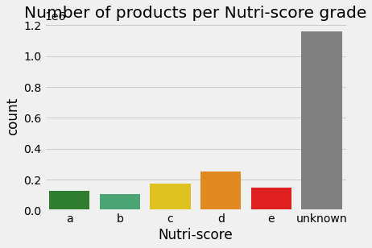

```python
sns.countplot(x="nutriscore_grade",data=df, palette = custom_palette)
plt.title("Number of products per Nutri-score grade")
plt.xlabel("Nutri-score")
plt.show()
```

### 3.2 Distribution

Back to table of contents

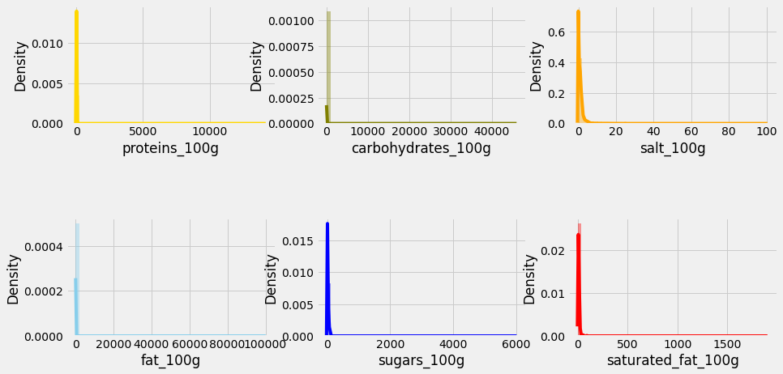

```python
f, axes = plt.subplots(2, 3, figsize=(14, 7))
plt.subplots_adjust(hspace = 0.8)
sns.distplot( df["proteins_100g"] , color="gold", ax=axes[0, 0])
sns.distplot( df["carbohydrates_100g"] , color="olive", ax=axes[0, 1])
sns.distplot( df["fat_100g"] , color="skyblue", ax=axes[1, 0])
sns.distplot( df["sugars_100g"] , color="blue", ax=axes[1, 1])
sns.distplot( df["salt_100g"] , color="orange", ax=axes[0, 2])
sns.distplot( df["saturated_fat_100g"] , color="red", ax=axes[1, 2])
plt.show()
```

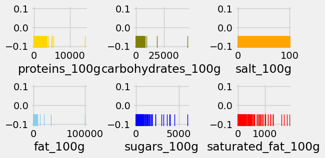

```python
f, axes = plt.subplots(2, 3, figsize=(6, 3),dpi=100)
plt.subplots_adjust(hspace = 0.8)
plt.subplots_adjust(wspace = 0.8)
sns.rugplot(x='proteins_100g',data=df,height=0.3,color='gold', ax=axes[0, 0])
sns.rugplot(x='carbohydrates_100g',data=df,height=0.3,color='olive', ax=axes[0, 1])
sns.rugplot(x='fat_100g',data=df,height=0.3,color='skyblue', ax=axes[1, 0])
sns.rugplot(x='sugars_100g',data=df,height=0.3,color='blue', ax=axes[1, 1])
sns.rugplot(x='salt_100g',data=df,height=0.3,color='orange', ax=axes[0, 2])
sns.rugplot(x='saturated_fat_100g',data=df,height=0.3,color='red', ax=axes[1, 2])
```

The shape of the data in the distribution shows that it is positively skewed meaning that the results are bent towards the lower side. This shape is not desirable for the distribution as this high level of shrewdness can cause misleading results.

```python
col_nutrition = df.filter(regex=("100g")).columns
```

```python
for col in df[col_nutrition].columns :
    print(col + " Skewness: %f" % df[col].skew())
    print(col +" Kurtosis: %f" % df[col].kurt())
```

```
energy_kcal_100g Skewness: 1398.377095
energy_kcal_100g Kurtosis: 1956883.181289
fat_100g Skewness: 1004.425502
fat_100g Kurtosis: 1195616.037640
saturated_fat_100g Skewness: 37.294439
saturated_fat_100g Kurtosis: 5014.708154
carbohydrates_100g Skewness: 359.676046
carbohydrates_100g Kurtosis: 271650.932152
sugars_100g Skewness: 33.287772
sugars_100g Kurtosis: 6060.211043
proteins_100g Skewness: 228.813517
proteins_100g Kurtosis: 113112.900181
salt_100g Skewness: 12.723838
salt_100g Kurtosis: 248.125740
```

The skewness value confirms that the data shape is positively skewed. For a normal distribution, the skewness should be around 0.

Becouse the shape of the data is tall and thin, and the kurtosis value is bigger than 3 the distribution is leptokurtic. This high value means that the data can contain heavy outliers.

### 3.3 Correlation matrix

Back to table of contents

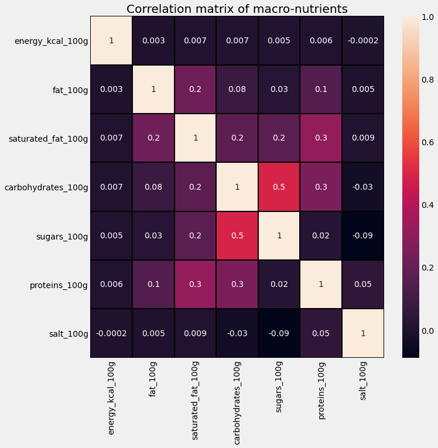

```python
matrix=df[col_nutrition].corr()
fig, ax = plt.subplots(figsize=(10,10))
plt.title("Correlation matrix of macro-nutrients")
sns.heatmap(matrix,annot=True, fmt='.1g',linewidths=1, linecolor='black', ax=ax)
plt.show()
```

### 3.4 Feature comparison

Back to table of contents

Fat vs Saturated fat

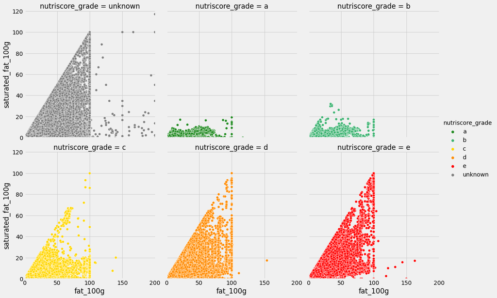

```python
temp = df[["fat_100g",	"saturated_fat_100g","nutriscore_grade"]]
sns.relplot(x="fat_100g", y = "saturated_fat_100g",data=temp,kind="scatter",
            col="nutriscore_grade", col_wrap=3,hue="nutriscore_grade",palette = custom_palette,
            col_order=["unknown","a","b","c","d","e"])
plt.ylim(0,120)
plt.xlim(0,200)
plt.show()
```

Carbs vs Sugar

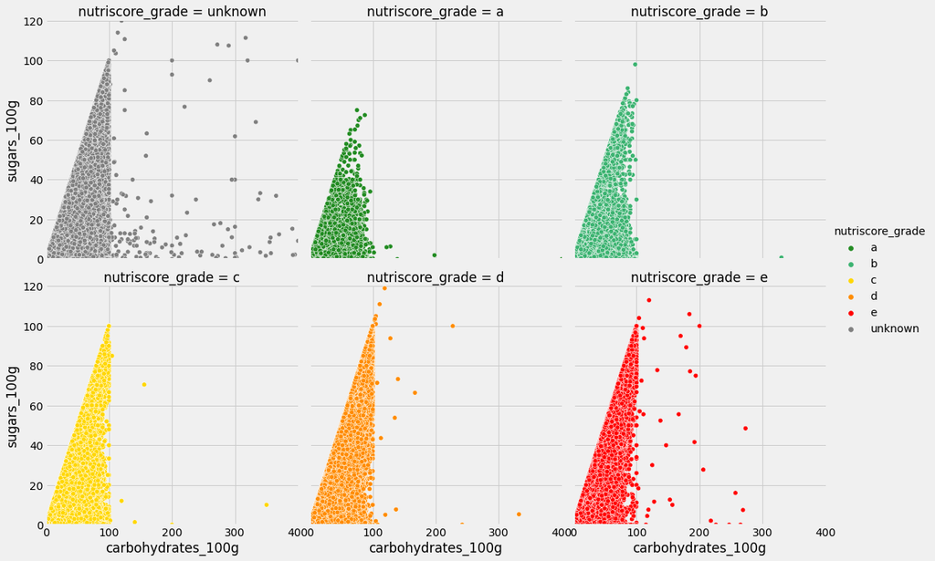

```python
temp = df[["carbohydrates_100g",	"sugars_100g","nutriscore_grade"]]
sns.relplot(x="carbohydrates_100g", y = "sugars_100g",data=temp,kind="scatter",
            col="nutriscore_grade", col_wrap=3,hue="nutriscore_grade",palette = custom_palette,
            col_order=["unknown","a","b","c","d","e"])
plt.ylim(0,120)
plt.xlim(0,400)
plt.show()
```

Carbs vs proteins

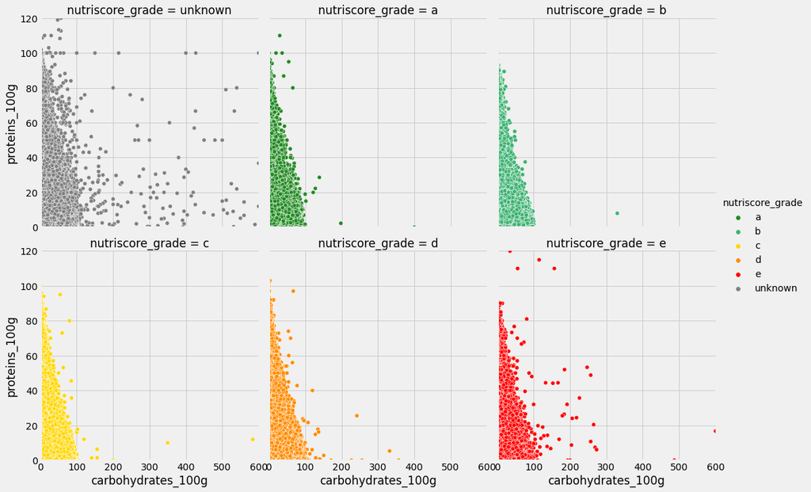

```python
temp = df[["carbohydrates_100g",	"proteins_100g","nutriscore_grade"]]
sns.relplot(x="carbohydrates_100g", y = "proteins_100g",data=temp,kind="scatter",
            col="nutriscore_grade", col_wrap=3,hue="nutriscore_grade",palette = custom_palette,
            col_order=["unknown","a","b","c","d","e"])
plt.ylim(0,120)
plt.xlim(0,600)
plt.show()
```

Proteins vs Fat

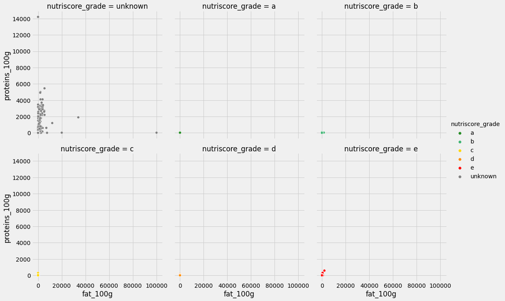

```python
temp = df[["fat_100g",	"proteins_100g","nutriscore_grade"]]
sns.relplot(x="fat_100g", y = "proteins_100g",data=temp,kind="scatter",
            col="nutriscore_grade", col_wrap=3,hue="nutriscore_grade",palette = custom_palette,
            col_order=["unknown","a","b","c","d","e"])
plt.show()
```

Proteins vs Saturated fat

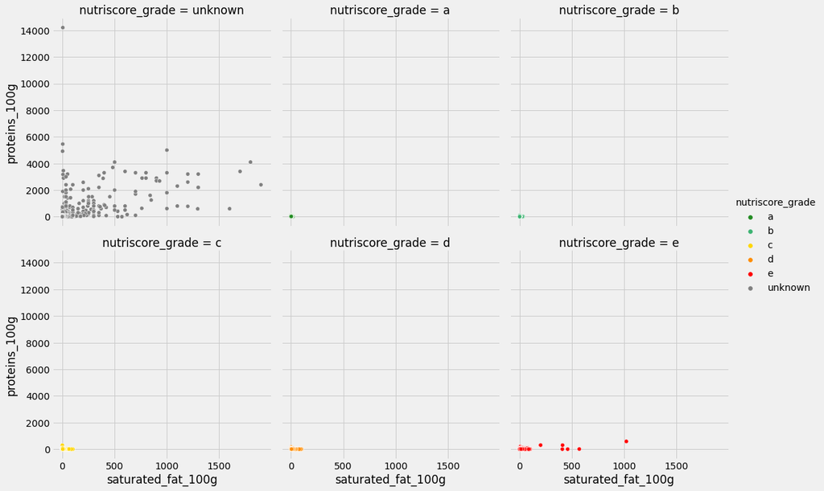

```python
temp = df[["saturated_fat_100g",	"proteins_100g","nutriscore_grade"]]
sns.relplot(x="saturated_fat_100g", y = "proteins_100g",data=temp,kind="scatter",
            col="nutriscore_grade", col_wrap=3,hue="nutriscore_grade",palette = custom_palette,
            col_order=["unknown","a","b","c","d","e"])
plt.show()
```

Proteins vs Carbs

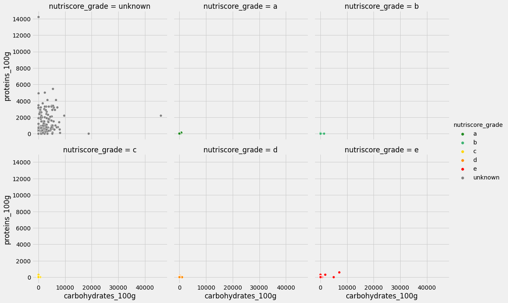

```python
temp = df[["carbohydrates_100g",	"proteins_100g","nutriscore_grade"]]
sns.relplot(x="carbohydrates_100g", y = "proteins_100g",data=temp,kind="scatter",
            col="nutriscore_grade", col_wrap=3,hue="nutriscore_grade",palette = custom_palette,
            col_order=["unknown","a","b","c","d","e"])
plt.show()
```

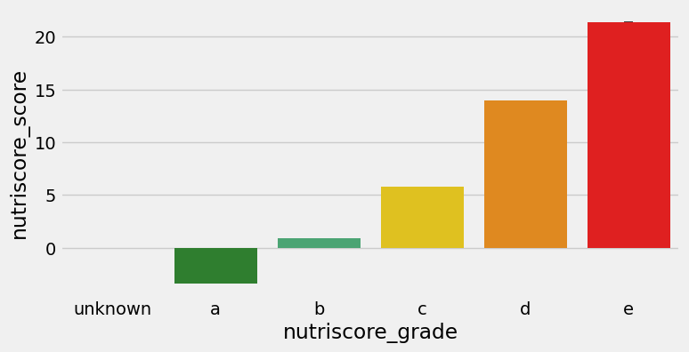

```python
plt.figure(figsize=(8,4),dpi=100)
sns.barplot(x="nutriscore_grade", y="nutriscore_score", data=df,order = ["unknown","a","b","c","d","e"], palette = custom_palette)
```

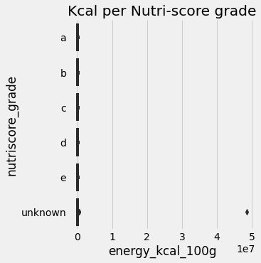

```python
sns.catplot(x="energy_kcal_100g",y="nutriscore_grade",data=df,kind="box")
plt.title("Kcal per Nutri-score grade")
plt.show()
```

### 4.0 Scaling the dataset PCA

Back to table of contents

```python
from sklearn import decomposition
from sklearn import preprocessing

col_nutrition = df.filter(regex=("100g")).columns

# number of components to calculate
n_comp = 2

#selection of the columns
data_pca = df[col_nutrition]

features = df[col_nutrition].columns

# preparing data
X = data_pca.values

# Centering and Reduction
std_scale = preprocessing.StandardScaler().fit(X)
X_scaled = std_scale.transform(X)

# Calculation of principal components
pca = decomposition.PCA(n_components=n_comp)
pca.fit(X_scaled)
```

```
PCA(n_components=2)
```

Bulding the scaled dataframe for nutriscore label model

```python
# using known nutriscore only to build model
data_scaled = pd.concat([pd.DataFrame(X_scaled, columns=col_nutrition),df["nutriscore_grade"]], axis = 1)
data_scaled.to_csv("data/data_scaled_1.csv", index=False)
```